# Chapter 2 - Small Worlds and Large Worlds

Florian Sckade

All statistical modeling has two frames:

- The small world of the model itself: This is the *self-contained logical world of the model* without any surprises and with all possibilities nominated.
- the large world in which we hope to deploy the model in: This is the broader context, which very well might hold surprises.

> The model is always an incomplete representation of the large world. The bayesian model advantage is that alternative model could make better use of the available information in the data and thus support better decisions, **assuming** the small world is an accurate description of the real world.

## Building a Model

1. **Data story**: Motivate the model by narrating how the data might arise.  
   The story of how the data came to be can be descriptive or causal. The former specifies relationships used to predict outcomes, given observations, while the latter seeks to explain how some events produce other events. Any causal story can also be descriptive, but the other way around is rather difficult. A data story can be motivated by trying to explain how each piece of data is created, which can include both the underlying reality as well as the sampling process. After formulating the data story, it needs to be translated into a formal probability model.
2. **Update**: Educate your model by feeding it the data.  
   A Bayesian model begins with a prior set of plausibilities assigned to every possibility. In light of data, these are update to produce the posterior plausibilities.
3. **Evaluate**: All statistical models require supervision, leading to model revision.  
   The Bayesian model learns in an optimal way in the small world. Notes: (i) The model’s certainty is no guarantee that the model itself is a good one. Its inference can be very confident, but may be produced by a misleading model. (ii) The model’s outputs need to be supervised and critiqued in light of its assumptions.

## Components of the model

Unobserved variables are usually called *parameters* and need to be inferred from other variables, which can be observed. Once the variables are listed, each has to be defined. A distribution function assigned to an observed variable is called a *likelihood*. For every parameter the Bayesian machine has to consider, a distribution of prior plausibility, the *prior*, has to be supplied. In the *subjective Bayesian* approach, priors can be chosen according to the beliefs of the analyst in question. Since priors are essentially assumptions, they should be interrogated as such - meaning different priors can be used to check how sensitive the inference of the model is to its assumptions.

> “No one is required to swear an oath to the assumptions of a model, and no set of assumptions deserves our obedience.”

## Bayes Theorem

In this explanation from the book, $W$ and $L$ are counts of variables, while $p$ is the unobserved variable.

The Bayesian model seeks to update all the prior distributions to their posterior distributions. This function contains the releative plausibility of different parameter values, given the data and model. Here, this is $\text{Pr}(p|W, L)$, the probability of each possible value of p, given the observed values of $W$ and $L$.

The joint probability of the data $W$ and $L$ and any value of $p$ is:
$$\text{Pr}(W, L, P) = \text{Pr}(W, L \vert p) \text{Pr}(p)$$
Meaning the probability of $W$, $L$ and $p$ is the product of $\text{Pr}(W, L \vert p)$ and the prior probability$\text{Pr}(p)$. In the same vein, the following is true:
$$\text{Pr}(W, L, p) = \text{Pr}(p \vert W, L) \text{Pr}(W, L)$$
Since both of these expressions are equal, this can be solved for the distribution of interest:
$$\begin{aligned}
\text{Pr}(W, L \vert p)\text{Pr}(p) & = \text{Pr}(p \vert W, L) \text{Pr}(W, L) \\ \\
\text{Pr}(p|W,L) & = \frac{\text{Pr}(W,L|p)\text{Pr}(p)}{\text{Pr}(W,L)}
\end{aligned}$$
In word form:

$$\text{Posterior} = \frac{\text{Probability of data} \times \text{Prior}}
{\text{Average Probability of data}}$$

Key takeaway: The posterior is proportional to the product of the prior and the probability of the data.

> Bayesian data analysis is not about Bayes’ theorem. Frequentists make use of it as well. Where Bayesian approaches differ, is their use of Bayes’ theorem to quantify uncertainty about theoretical entities that cannot be observed (parameters, models).

## Motors

### Grid Approximation

Steps:

1. Define the grid.
2. Compute the value of the prior at each parameter value on the grid
3. Compute the likelihood at each parameter value.
4. Compute the unstandardized posterior at each parameter value, by multiplying the prior by the likelihood
5. Standardize the posterior, by dividing each value by the sum of all values.

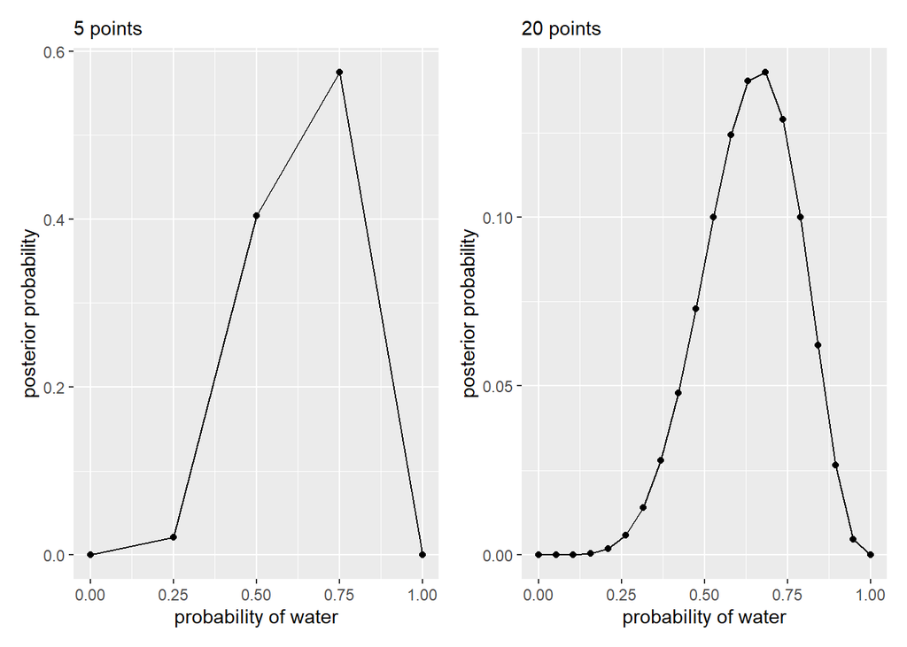

```r
library(tidyverse)
library(patchwork)
p1 <- data.frame(p_grid = seq(0, 1, length.out = 20),            # define grid
           prior  = 1) %>%                                       # define prior
  mutate(likelihood = dbinom(6, size = 9, prob = p_grid)) %>%    # calculate likelihood
  mutate(unstd.posterior = likelihood * prior) %>%               # calculate posterior
  mutate(posterior = unstd.posterior / sum(unstd.posterior)) %>% # std posterior
  ggplot(aes(x = p_grid, y = posterior)) +
  geom_point() +
  geom_line() +
  labs(subtitle = "20 points",
       x = "probability of water",
       y = "posterior probability")

p2 <- data.frame(p_grid = seq(0, 1, length.out = 5),             # define grid
           prior  = 1) %>%                                       # define prior
  mutate(likelihood = dbinom(6, size = 9, prob = p_grid)) %>%    # calculate likelihood
  mutate(unstd.posterior = likelihood * prior) %>%               # calculate posterior
  mutate(posterior = unstd.posterior / sum(unstd.posterior)) %>% # std posterior
  ggplot(aes(x = p_grid, y = posterior)) +
  geom_point() +
  geom_line() +
  labs(subtitle = "5 points",
       x = "probability of water",
       y = "posterior probability")

p2 | p1
```

### Quadratic Approximations

Under pretty general conditions, the region near the peak of the posterior distribution will be nearly Gaussian / normal, which means the posterior can be approximated by a Gaussian distribution. The normal distribution is nice, because it is completely defined by its $\mu$ and $\sigma^2$. This is called *quadratic approximation*, because the log of the normal distribution is a parabola, which is a quadratic function. This means that the quadratic approximation represents any log-posterior with a parabola.

Steps:

1. Find the posterior mode. Usually done via some optimization over the posterior distribution.
2. Estimate the curvature around the mode, to then compute a quadratic approximation of the complete posterior distribution.

The book utilizes the function `quaop()` from the `rethinking` package to compute this approximation.

```r
library(rethinking)

globe.qa <- quap(
  alist(
    W ~ dbinom(W + L, p), # binomial likelihood
    p ~ dunif(0, 1)       # uniform prior
  ),
  data = list(W = 6, L = 3)
  )

precis(globe.qa)
```

```
##        mean        sd      5.5%     94.5%
## p 0.6666673 0.1571336 0.4155374 0.9177972
```

This means, *assuming the posterior distribution is gaussian*, it has a mean of $p = 0.67$ and its standard deviation is $0.16$.

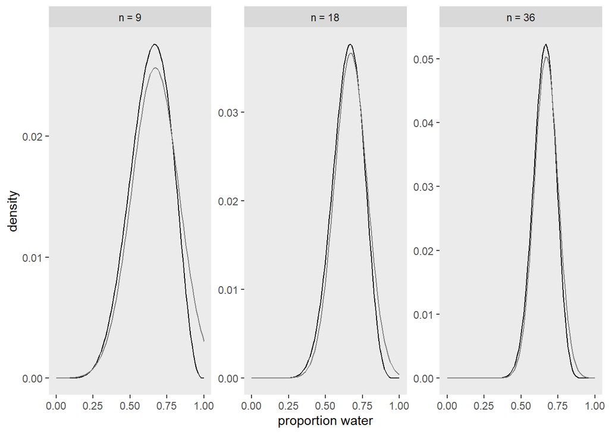

```r
# taken from statistical rethinking recoded
n_grid <- 100

data <- tibble(p_grid                  = seq(from = 0, to = 1, length.out = n_grid) %>% rep(., times = 3),
       prior                   = 1,
       w                       = rep(c(6, 12, 24), each = n_grid),
       n                       = rep(c(9, 18, 36), each = n_grid),
       m                       = .67,
       s                       = rep(c(.16, .11, .08), each = n_grid)) %>%
  mutate(likelihood            = dbinom(w, size = n, prob = p_grid)) %>%
  mutate(unstd_grid_posterior  = likelihood * prior,
         unstd_quad_posterior  = dnorm(p_grid, m, s)) %>%
  group_by(w) %>%
  mutate(grid_posterior        = unstd_grid_posterior / sum(unstd_grid_posterior),
         quad_posterior        = unstd_quad_posterior / sum(unstd_quad_posterior),
         n = str_c("n = ", n)) %>%
  mutate(n = factor(n, levels = c("n = 9", "n = 18", "n = 36")))

data %>%
  ggplot(aes(x = p_grid)) +
  geom_line(aes(y = grid_posterior)) +
  geom_line(aes(y = quad_posterior),
            color = "grey50") +
  labs(x = "proportion water",
       y = "density") +
  theme(panel.grid = element_blank()) +
  facet_wrap(~n, scales = "free")
```

```r
head(data)
```

```
## # A tibble: 6 x 11
## # Groups:   w [1]
##   p_grid prior     w n         m     s likelihood unstd_grid_post~
##    <dbl> <dbl> <dbl> <fct> <dbl> <dbl>      <dbl>            <dbl>
## 1 0          1     6 n = 9  0.67  0.16   0.        0
## 2 0.0101     1     6 n = 9  0.67  0.16   8.65e-11  0.0000000000865
## 3 0.0202     1     6 n = 9  0.67  0.16   5.37e- 9  0.00000000537
## 4 0.0303     1     6 n = 9  0.67  0.16   5.93e- 8  0.0000000593
## 5 0.0404     1     6 n = 9  0.67  0.16   3.23e- 7  0.000000323
## 6 0.0505     1     6 n = 9  0.67  0.16   1.19e- 6  0.00000119
## # ... with 3 more variables: unstd_quad_posterior <dbl>, grid_posterior <dbl>,
## #   quad_posterior <dbl>
```

Quadratic approximation tends to work better with more data.

### Markov chain Monte Carlo

MCMC procedures draw samples from the posterior, instead of estimating the posterior distribution directly. More on this in Chapter 9.

## Summary

Bayesian inference is, at its core, about inference based on a posterior probability distribution.

> “Posterior Probabilities state the relative numbers of ways each conjectured cause of the data could have produced the data. These relative numbers indicate plausibilities of the different conjectures. These plausiblities are updated in light of observations through Bayesian updating.”